# Introdução à Linguagem R

Prof. Alessandro de Castro Corrêa

27 fevereiro, 2023

# 1 Aspectos gerais do R

No sítio oficial do R project (https://www.r-project.org/), é possível encontrar inúmeras informações sobre o ambiente, literatura relacionada e contribuições em diversas formatos.

[figure not shown]

Sítio oficial do R Project

No sítio do R project, na guia lateral esquerda, destaca-se o CRAN que é a rede de distribuição do R (*Comprehensive R Archive Network - CRAN*) formada por vários *mirrors* ou espelhos que são servidores localizados em diversos países que armazenam os arquivos de instalação do R e de seus diversos pacotes adicionais.

Para baixar os arquivos de instalação, um *mirror* deve ser escolhido. Normalmente se escolhe um no país em que se está localizado em decorrêancia da proximidade.

## 1.1 Pontos fortes e fracos do R

| Pontos fortes | Pontos fracos |
| --- | --- |
| Fácil de programar | Não possui menu guia de comandos |
| Gratuito | sem garantia de suporte |
| Muitas funções | As vezes, são difíceis de encontrar as funções |
| Muito flexível | Muitas opções podem confundir |
| Excelente capacidade gráfica | Leva algum tempo para aprender |

## 1.2 Para instalar o R

O executável de instação do R, para a plataforma Windows, pode ser descarregada da rede de distribuição do R (Comprehensive R Archive Network - CRAN) que é hospedado no seguinte endereço:

https://cran.r-project.org/

[figure not shown]

CRAN

Há opções de instalaçães nas plataformas Windows, Linux ou MAC. Para a plataforma Windows siga os seguites passos:

1. CRAN -> seleciona CRAN Mirrors (Preferencialmente um do Brasil)
2. Download R for Windows -> base -> Download R 4.0.3 for Windows (versão em 26/11/2020)
3. Baixar, instalar com as configurações sugeridas pelo instalador (*default*)

Após a instação, basta clicar sobre o ícone do R para que a sua interface gráfica seja aberta que é a face do R ou o R GUI (*Graphical User Interface - GUI*), também denominado popularmente como R básico.

[figure not shown]

Interface gráfica básica do R

O GUI permite do usuário interaja com o programa; todavia, essa interação pode ser mais amigável e intergrada mais facilmente com outros recursos quando realizada a partir do RStudio cuja instalação será descrita a seguir:

## 1.3 Para instalar o RStudio

O RStudio é uma interface de desenvolvimento integrada (IDE) que atua conjudado com o R, facilitando as operações e integrações com outros recursos como o Rmardown. Possibilita desde o preenchimento automático de palavras (o que ajuda muito), a criação de relatórios em formatos como HTML, PDF, Word e PowerPoint, e a criação de novos pacotes.

Para a sua instalação, siga as instruções abaixo:

1. No navegador escreva “rstudio download” que será exido o sítio para descarrear o executável de instalação ou utilize o endereço o seguinte endereço

https://www.rstudio.com/products/rstudio/download/

2. Estão disponíveis versões comerciais e uma versão gratuita. Opte pela versão RStudio Desktop Open Source License (FREE).

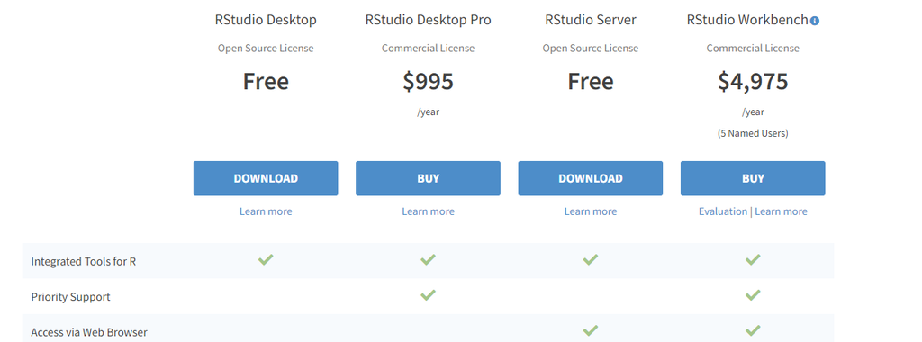

Versões do RStudio disponíveis para download

3. Windows 10/8/7
4. Basta clicar no botão de download
5. Baixar, instalar com as configurações sugeridas pelo instalador

## 1.4 Tutoriais

Atualmente há diversos materiais instrucionais sobre o R em Português na internet. O vídeo [Como organizar um Projeto no R Studio?](https://youtu.be/0NbAKipZ6sU) é muito útil e foi disponibilizado por Gustavo B Paterno no Youtube.

## 1.5 Citação

### 1.5.1 Citação do R

O comando `citation()` permite exibir as referências do R e dos pacotes, inclusive com o entrada Bibtex para Latex.

```r
citation()
```

```
##
##
##   R Core Team (2022). R: A language and environment for statistical
##   computing. R Foundation for Statistical Computing, Vienna, Austria.
##   URL https://www.R-project.org/.
##
## A BibTeX entry for LaTeX users is
##
##   @Manual{,
##     title = {R: A Language and Environment for Statistical Computing},
##     author = {{R Core Team}},
##     organization = {R Foundation for Statistical Computing},
##     address = {Vienna, Austria},
##     year = {2022},
##     url = {https://www.R-project.org/},
##   }
##
## We have invested a lot of time and effort in creating R, please cite it
## when using it for data analysis. See also 'citation("pkgname")' for
## citing R packages.
```

```r
citation("stats") # referencia de pacote
```

```
##
## The 'stats' package is part of R.  To cite R in publications use:
##
##   R Core Team (2022). R: A language and environment for statistical
##   computing. R Foundation for Statistical Computing, Vienna, Austria.
##   URL https://www.R-project.org/.
##
## A BibTeX entry for LaTeX users is
##
##   @Manual{,
##     title = {R: A Language and Environment for Statistical Computing},
##     author = {{R Core Team}},
##     organization = {R Foundation for Statistical Computing},
##     address = {Vienna, Austria},
##     year = {2022},
##     url = {https://www.R-project.org/},
##   }
##
## We have invested a lot of time and effort in creating R, please cite it
## when using it for data analysis. See also 'citation("pkgname")' for
## citing R packages.
```

Para a referenciar do RStudio, use

```r
RStudio.Version()
```

## 1.6 Pacotes

Pacotes são conjuntos de funções e dados destinados a determinado propósito. Quando o R é instalado, já vem com um conjunto de pacotes básicos instalados.

Para exibir os pacotes instalados, digite o seguinte comando no console:

```r
library()
```

### 1.6.1 Carregando pacotes

Mesmos que os pacotes já estejam instalados, para que seus recursos sejam ativados, precisam ser carregados, o que pode ser realizado por um dos comandos a seguir:

```r
library(nome.do.pacote)
require(nome.do.pacote)
```

O RStudio oferece uma segunda opção de carregar pacote por meio da aba **Packages**, no canto inferior direto. Clique nessa aba que serão exibidos os pacotes instalados e marque o pacote que deseja carregar.

Para “descarregar” um pacote, deigite:

```r
detach(package:nome.do.pacote)
```

### 1.6.2 Instalação de pacotes

Exitem, no entanto, diversos pacotes para os mais variados fins. Para utilizar os recursos desses pacotes, eles devem ser primeiramente instalados e, posteriormente, carregados.

Os pacotes ficam armazenados em repositórios (*repository*), detro os quais, os mais populares são:

- **CRAN** (https://cran.r-project.org/) que é o repositário oficial do R, no qual os pacotes, passam por um processo de revisão antes de estarem disponíveis para instalação;
- **Github** (https://github.com/) que é um repositório popular de projetos *open source* cada vez mais utilizado por desenvolvedores de R. Deve-se apenas ter precaução com os pacotes do Github pelo fato de não passarem por processo de revisão, uma vez que são oferecidos diretamente por seus autores.

A maior parte dos pacotes do R estão hospedados no CRAN (http://cran.r-project.org). Em 15/01/2020, havia 18733 pacotes no CRAN.

No RStudio, há três maneiras de instalar pacotes: duas da internet, (a) digitando o comando `install.packages()` (igual no R básico), (b) por meio da aba `Packages` e (c) a partir de um arquivo armazenado localmente.

#### 1.6.2.1 Instação de pacotes do CRAN

A primeira, envolve a digitação do comando de instalação de um pacote cuja sintaxe é a seguinte:

```r
install.packages("nome.do.pacote")
```

Por exemplo, para instalar o pacote `car`, digite:

```r
install.packages("car")
```

O R ou o R Studio abrirá uma janela para a seleção do Mirror do qual você deseja baixar o pacote. Escolha o Mirror mais próximo, apesar de que, atualmente, isso não faz muita diferença, por causa da velocidade da internet. Em seguida, a instalação deve ocorrer sem problemas.

Caso o pacote já tenha sido instalado anteriormente, esse procedimento irá somente atualizá-lo.

Caso se deseje instalar mais de um pacote num único comando, pode-se reunir os nomes inserido na função `c("pacote1", "pacote2", ...)`, como a seguir:

```r
install.packages(c("car","readxl"))
```

Uma segunda maneira de instalar no RStudio, consiste em, na janela inferior direita, selecionar a aba **Packages**, depois clicar em **Install**. Uma janela de instalação direto do CRAN com um espaço para digitar o pacote desejado. A medida em que a palavra é digitada, é oferecida uma lista de pacotes cujos nomes se encaixam com as letras que vai sendo exibida. Basta selecionar o pacote dejesado em clicar no botão **install**.

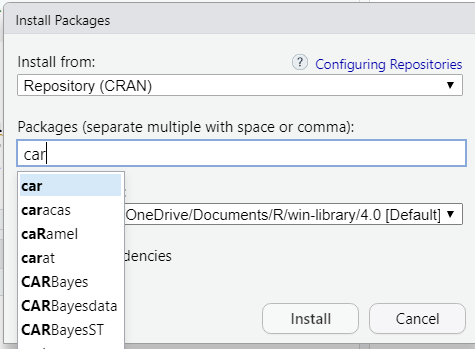

Janela de instação de pacotes do RStudio

#### 1.6.2.2 Instação de pacotes locais

Uma terceira maneira de instalar pacotes consiste em os obter de fontes locais, como um diretório do computador ou armazenados em um pendrive, o que pode ser muito útil em situação de dificuldades de acesso à internet. Repete-se o mesmo caminho para instação de pacote: selecionar a aba **Packages**, depois clicar em **Install**. Na Janela de instação, clicar aguia de seleção **Install from:**, naqual é possivel alternar entre insatalar do CRAN e de arquivos comprimidos nos formatos .zip e tar.gz. Nesse momento, o uma janela de navegação é aberta para se selecionar o pacote desejado.

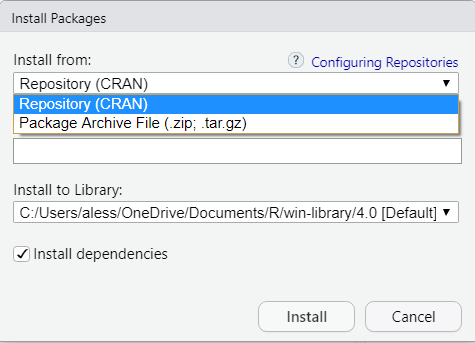

Seleção de fontes de pacotes no RStudio

#### 1.6.2.3 Instação de pacotes do GitHub

Há duas maneiras simples de instalar pacotes do GitHub:

- uma com a função `install_github()` do pacote `devtools` e
- outra com a função `githubinstall` do pacote `githubinstall`.

A diferença entre ambos reside na necessidade de indicar o nome do desenvolvendor, exigido no primeiro.

Para utilizar o comando `install_github()`, primeiro é necessário instalar o pacote `devtools`, a sintaxe e um exemplo, são apresentados abaixo:

```r
install.packages("devtools")
devtools::install_github("nome-do-repo/nome-do-pacote")
devtools::install_github("rstudio/shiny")
```

Atenção para a necessidade de indicar que o pacote `shiny` é desenvolvido por **rstudio**.

Para utilizar o comando `githubinstall()`, primeiro é necessário instalar o pacote `githubinstall`, a sintaxe e um exemplo, são apresentados abaixo:

```r
install.packages("githubinstall")
library(githubinstall)
githubinstall("shiny")
```

Como se pode observar, não há a necessidade de indicar o nome do desenvolvedor.

Se o houver vários desenvolvedores que tenham pacotes com o mesmo nome, o comando retorna uma lista de pacotes relacionados por desenvolvedor, para que você escolha de quem deseja baixar.

```r
gh_suggest_username("hadly") # sugere nome

# lista de pacotes a partir de palavra chave
busca_packages <- gh_search_packages("experiment")
View(busca_packages)
```

### 1.6.3 Removendo pacotes

O comando `remove.packages("")` remove pacotes.

```r
remove.packages("beyonce")
```

### 1.6.4 Atualização de pacotes

Os comando `old.packages()` retorna uma relação de pacotes desatualizados:

```r
old.packages()
```

Para atualizar pacotes, pode utilizar três opções: (*a*) reinstalando um pacote específico com `install.packages()`, (*b*) atualizando todos com `update.packages()`, esses dois escrenvendo no console todos no console, ou (*c*) utilizando o botão **Update** na aba **Packages** no terminal do RStudio

```r
install.packages("stats") # atualiza pacote
update.packages()         # atualiza todos
```

## 1.7 Comandos de operação básicas

| Comando | Ação |
| --- | --- |
| `getwd()` | Exibe o diretório de trabalho |
| `ls()` | Lista todos os objetos da área de trabalho atual |
| `ls(pat="m")` | Lista objetos com “m” no nome (pat = pattern) |
| `ls(pat="^m")` | Lista objetos que iniciam com “m” |
| `rm(x)` | Remove o objeto x |
| `rm(x,y)` | Remove os objetos x e y |
| `rm(list=ls())` | Remove todos os objetos da área de trabalho |
| `rm(list=ls(pat="^m"))` | Remove objetos que começam com “m” |
| `library()` | Mostra todos os pacotes instalados |
| `library(pacote)` | Carrega pacote |
| `example(comandoX)` | Mostrar exemplos do “comandoX” |
| `ls("package:base")` | Listar as funções e operações contidas no pacote base do R |
| `help(comandoX)` | Obter ajuda sobre o comando X |

## 1.8 Ajuda

Para obter ajuda sobre algum comando, basta digitar `help(comando)` ou `?comando`, como no exemplo a seguir em que se pede ajuda sobre o comando `sqrt`.

```r
help(sqrt) # ajuda
?sqrt      # mesmo que help
```

Os tópicos que são exibidos na ajuda, por padrão, são os seguintes:

Geralmente, o arquivo de help do R possui descrições e explicações detalhadas sobre as funções, com exemplos que valem a pena repetir. Os tópicos básicos da ajuda do R são os seguintes:

1. **Description**: decreve de maneira breve o uso do comando;
2. **Usage**: explica como o comando deve ser utilizado e como seus argumentos podem ser especificados;
3. **Arguments**: explica os argumentos do comando;
4. **Details**: acrescenta algumas explicações sobre a aplicação do comando;
5. **Value**: lista os resultados (*output*) gerados pelo comando;
6. **Note**: acrescenta algumas observações;
7. **Authors**: referencia os autores do comando;
8. **References**: referências das obras utilizadas no *help* e no comando;
9. **See also**: outros comandos relacionados;
10. **Examples**: exemplos do uso do comando.

Quando não se sabe o nome de uma função, o comando `help.search()` ou `??`pode ser utilizado para exibir todas as funções que citem uma palavra em sua documentação. No exemplo a seguir, são listados todos as funções que contenham a palavra “mean” em algum texto de sua documentação.

```r
help.search("mean")
??mean # o mesmo que help.search()
```

Quando não se sabe o nome exato da função, uma alternativa é o uso do comando `apropos()` que exibe a lista de funções que contenham o argumento informado como parte de seu nome. No exemplo a seguir que se buscam as funções cque contenham a palavra “mean” em seus nomes. Deve notar que a busca então é limitada aos nomes das funções enquanto `help.search()` faz a busca em toda a documentação, não somente no nome das funções.

```r
apropos("mean")
```

As vezes, é mais fácil aprender como se usa uma função por meio de exemplo. A função `exemple()` executa, no console, exemplos da função desejada, como demonstrado a seguir:

```r
example(mean)# exemplo da função mean

example(plot)# exemplos da função plot
```

A função `help.start()` abre uma janela de `help` com manuais, referências, materiais de ajuda do R para consulta.

```r
help.start()
```